# Лабораторная работа 3. Задание 1. Вариант 1

Дроздова Дарья, 5030102/80401

Файл trades.RData содержит данные Евростата о импорте и экспорте товаров партнеров Евросоюза (значения указаны в Евро). Нужно объединить таблицы в одну, убрать столбец с территорией торговли, оставить данные по экспорту и импорту. Отобразить структуру экспорта продукции из Евросоюза по ведущим партнерам в виде столбчатой диаграммы. Обозначить разные группы экспортируемых товаров разными цветами. Для каждого партнера подписать, какова доля (процент) каждой из групп экспортируемых товаров в общем экспорте.

Импортируем библиотеки

```r
library(ggplot2)
library(dplyr)
```

Загружаем данные

```r
load("trades.RData")
```

Функция для объединения таблиц

*Параметры*:

- trades - список таблиц

*Возвращает*: датафрейм с объединенными таблицами

```r
merge_trades <- function(trades) {
  c = trades[[1]]
  for (i in 2:length(trades)) {
    c = mapply(c, c, trades[[i]], SIMPLIFY=FALSE)
  }

  return (subset(as.data.frame(c), select = -geo ))
}
```

Функция для получения информации по импорту или экспорту

*Параметры*:

- all_trades - датафрейм с информацией об экспорте и импорте
- name_exp_imp - заголовок для поиска импорта или экспорта

*Возвращает*: датафрейм с информацией об импорте или об экспорте

```r
get_export_or_import <- function(all_trades, name_exp_imp) {
  return (all_trades[all_trades$indic_et == name_exp_imp, ])
}
```

Функция для построения графика

*Параметры*:

- data - датафрейм с информацией для построения графика
- x_data - значения x
- y_data - значения y
- fill_data - значения для легенды
- title - заголовок графика
- x_title - подпись для оси х
- y_title - подпись для оси y
- fill_title - заголовок легенды

*Возвращает*: построенный график

```r
build_graph <- function(data, x_data, y_data, fill_data, title, x_title, y_title, fill_title)  {
  return (ggplot(data, aes(x = x_data, y = y_data, fill = fill_data)) + geom_col(position = "dodge") +
    xlab(x_title) + ylab(y_title) +
    ggtitle(title) + scale_fill_discrete(name = fill_title))
}
```

Функция для построения графика с подписями

*Параметры*:

- data - датафрейм с информацией для построения графика
- x_data - значения x
- y_data - значения y
- fill_data - значения для легенды
- label_data - значения для подписи
- title - заголовок графика
- x_title - подпись для оси х
- y_title - подпись для оси y
- fill_title - заголовок легенды

*Возвращает*: построенный график

```r
build_cord_graph <- function(data, x_data, y_data, fill_data, label_data, title, x_title, y_title, fill_title)  {
  ggplot(data, aes(x = x_data, y = y_data, group = fill_data)) +
    geom_col(aes(fill = fill_data)) +
    xlab(x_title) + ylab(y_title) +
    ggtitle(title) + scale_fill_discrete(name = fill_title) + coord_flip() +
    geom_text(aes(label = label_data), position = position_stack(vjust = 0.5))
}
```

Вызов функций

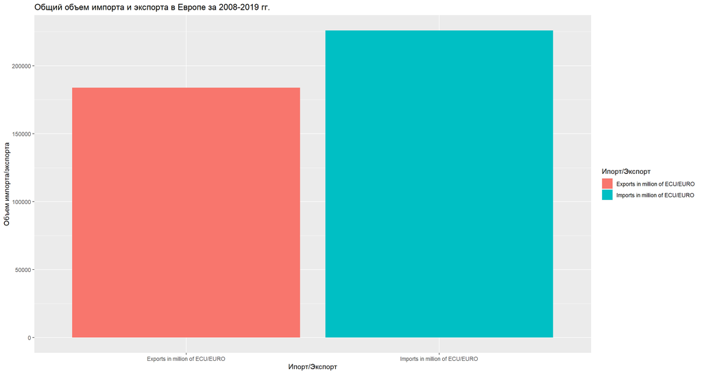

```r
all_trades = merge_trades(trades)

export_name = 'Exports in million of ECU/EURO'
import_name = 'Imports in million of ECU/EURO'
export = get_export_or_import(all_trades, export_name)
import = get_export_or_import(all_trades, import_name)
export_import = bind_rows(export, import)

all_export_import = build_graph(export_import,
                  export_import$indic_et,
                  export_import$values,
                  export_import$indic_et,
                  'Общий объем импорта и экспорта в Европе за 2008-2019 гг.',
                  'Ипорт/Экспорт',
                  'Объем импорта/экспорта',
                  'Ипорт/Экспорт')
all_export_import
```

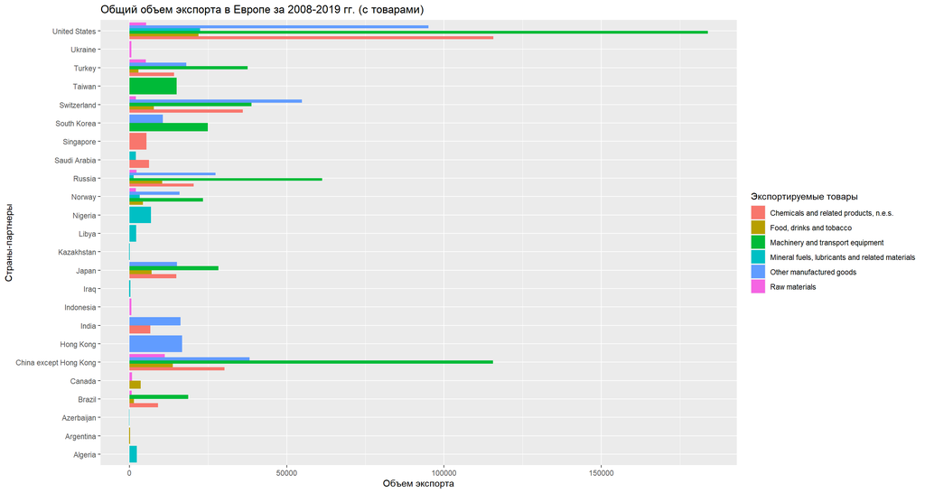

```r
export_products = build_graph(export,
                   export$partner,
                   export$values,
                   export$sitc06,
                   'Общий объем экспорта в Европе за 2008-2019 гг. (с товарами)',
                   'Страны-партнеры',
                   'Объем экспорта',
                   'Экспортируемые товары') + coord_flip()
export_products
```

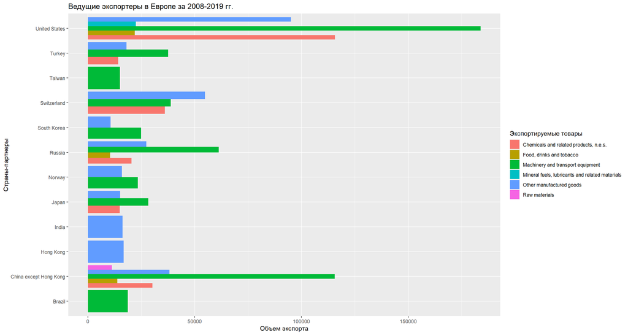

```r
export_lead_partners = subset(export, export$value > 10000)
lead_export_products =  build_graph(export_lead_partners,
                    export_lead_partners$partner,
                    export_lead_partners$values,
                    export_lead_partners$sitc06,
                    'Ведущие экспортеры в Европе за 2008-2019 гг.',
                    'Страны-партнеры',
                    'Объем экспорта',
                    'Экспортируемые товары') + coord_flip()
lead_export_products
```

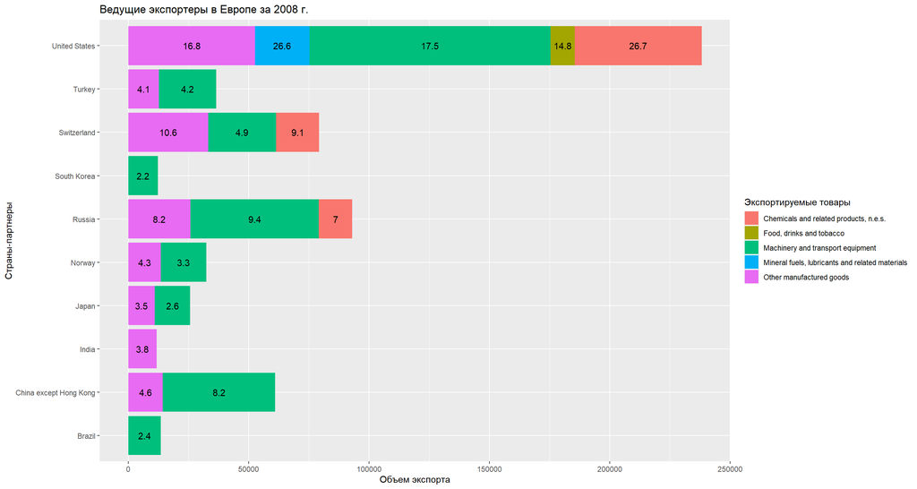

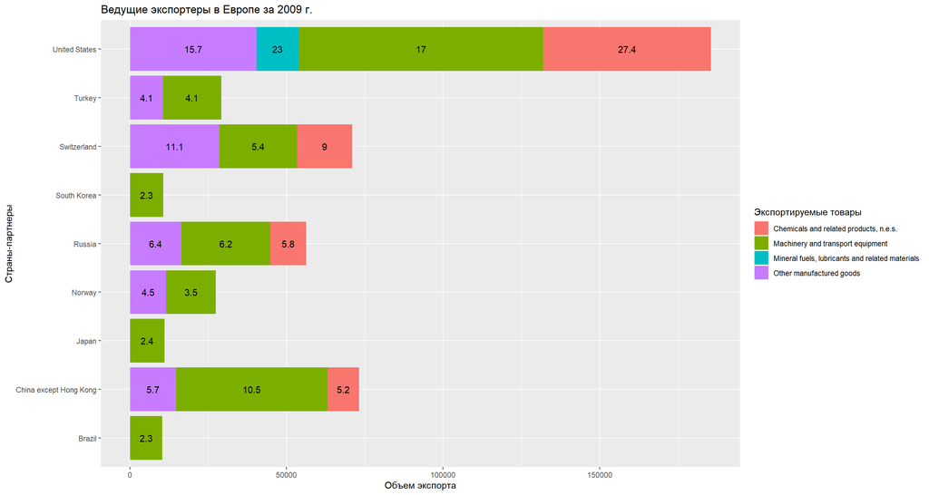

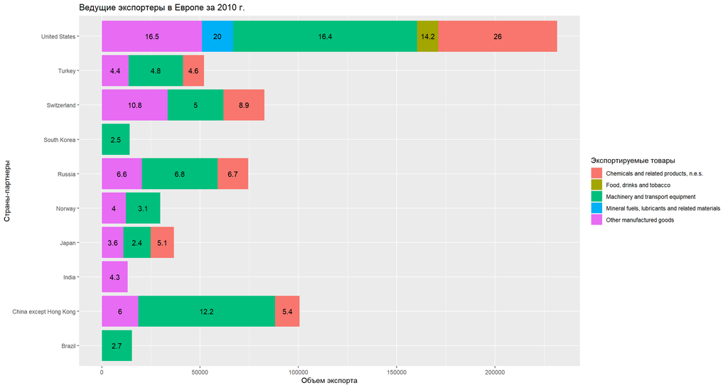

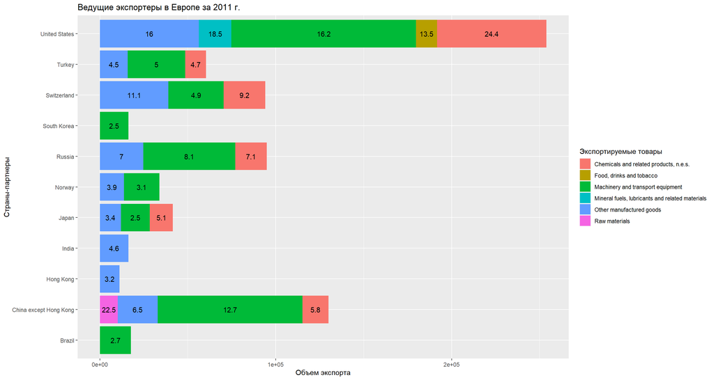

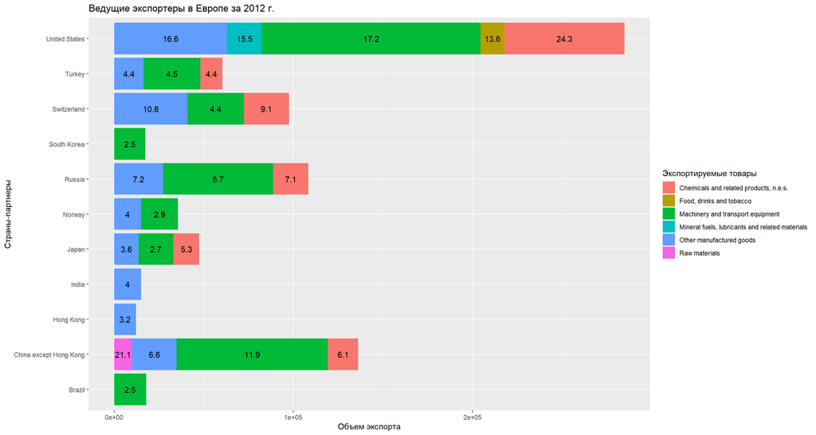

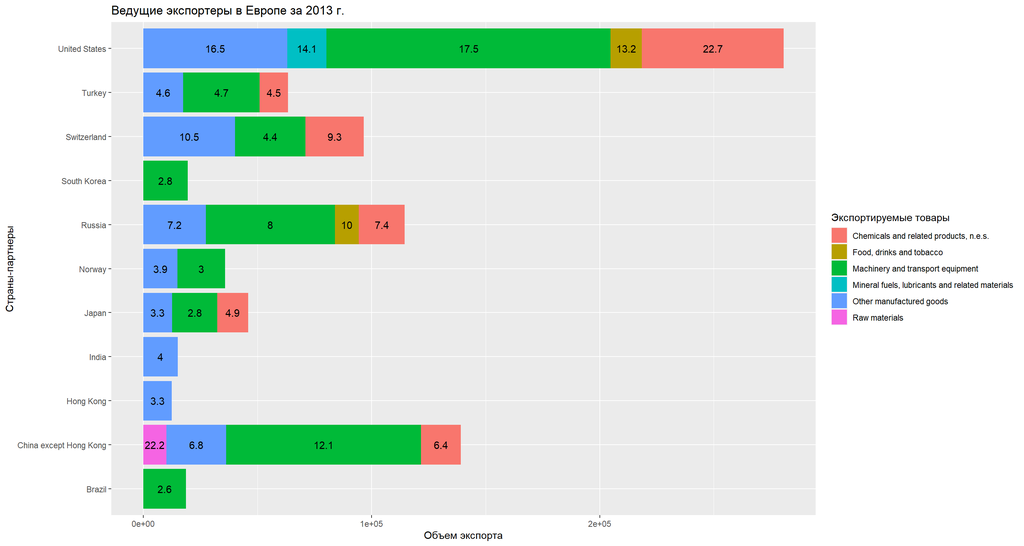

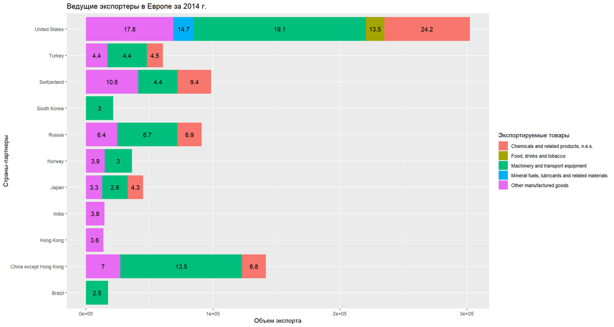

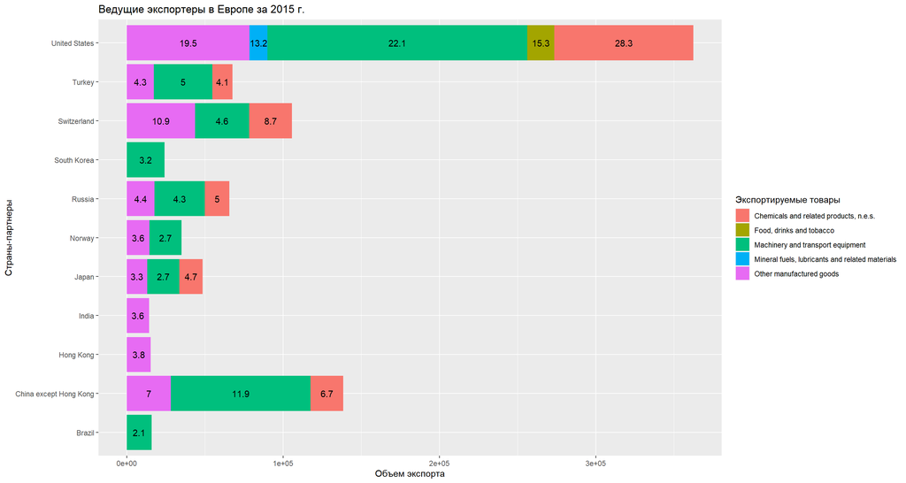

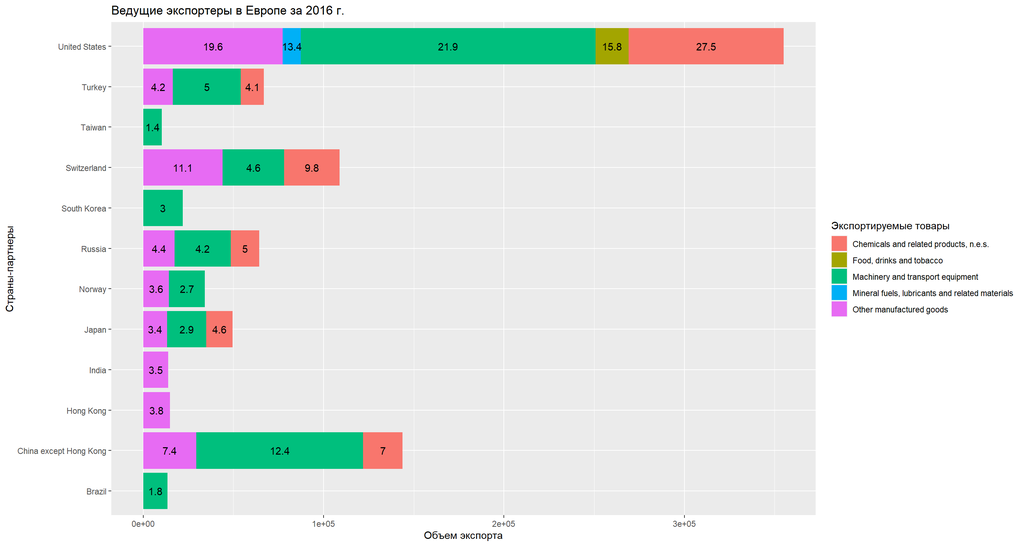

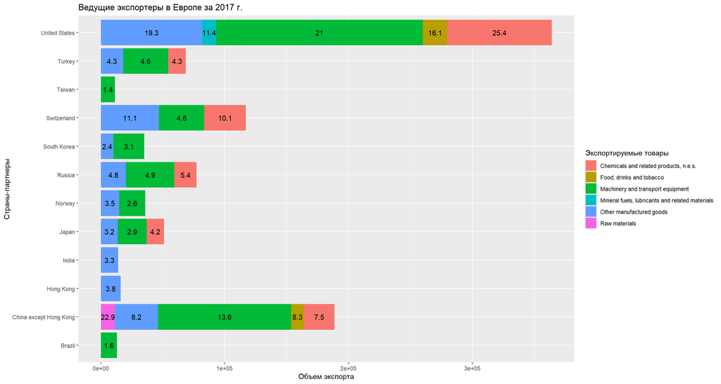

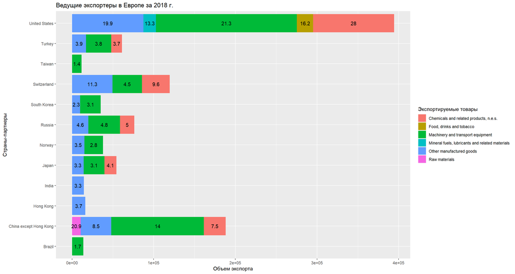

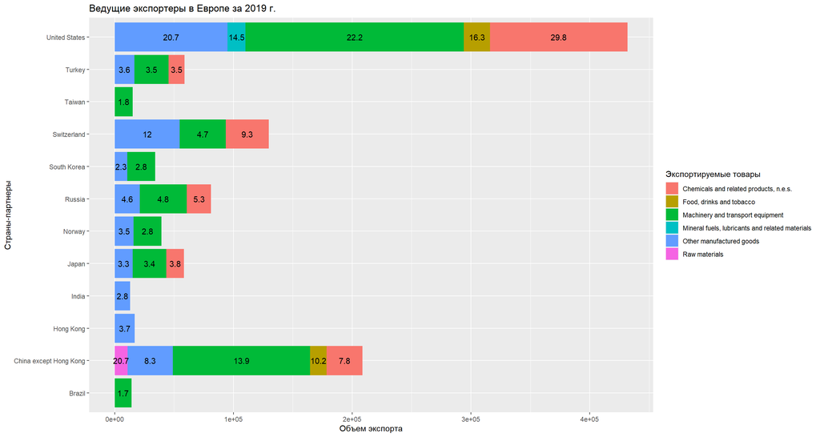

```r
share_export_name = 'Share of exports by partner (%)'
share_export = all_trades[all_trades$indic_et == share_export_name, ]
share_export_data = cbind(export, share = share_export$values)
dates = unique(share_export_data$time)
lapply(dates, function(date) {
  export_data = subset(share_export_data, share_export_data$time == date & share_export_data$value >= 10000)
  build_cord_graph(export_data,
              export_data$partner,
              export_data$values,
              export_data$sitc06,
              export_data$share,
              paste0('Ведущие экспортеры в Европе за ', substring(date, 1, 4), ' г.'),
              'Страны-партнеры',
              'Объем экспорта',
              'Экспортируемые товары')

})
```